# STATS 60 Rlab Session 3

# Function syntax

The most important syntax in R is the **function call**. All R syntax has function calls underlying it.

A function call consists of:

- Function name
- Parentheses, and
- A list of arguments within the parentheses

```r
function_name(<inputs to the function>,
              <arguments which change
              how the function operates>)
```

# Function example

```r
function_name(<inputs to the function>,
              <arguments which change
              how the function operates>)
```

```r
x <- c(-5, -3, -1, 1, 3, NA)
mean(x)
```

```
## [1] NA
```

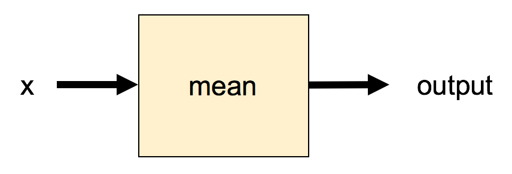

# Function example

```r
function_name(<inputs to the function>,
              <arguments which change
              how the function operates>)
```

```r
x <- c(-5, -3, -1, 1, 3, NA)
mean(x, na.rm = TRUE)
```

```
## [1] -1
```

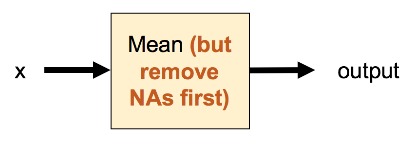

# Function calls read “inside out”

`abs(x)`: If `x` is positive, return `x`. If `x` is negative, return `x` without the negative sign.

```r
mean(abs(x), na.rm = TRUE)
```

```
## [1] 2.6
```

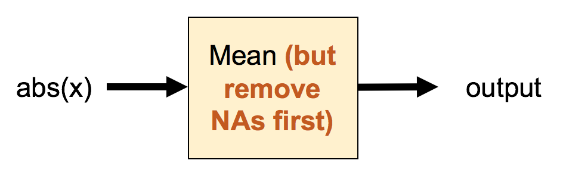

# Function calls read “inside out”

`abs(x)`: If `x` is positive, return `x`. If `x` is negative, return `x` without the negative sign.

```r
mean(abs(x), na.rm = TRUE)
```

```
## [1] 2.6
```

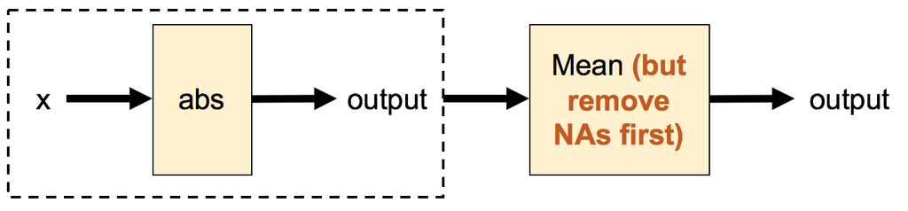

# A deeper look at functions

**Question:** How do we find out what a function does? What inputs does it accept, what does it output, etc…

# A deeper look at functions

**Question:** How do we find out what a function does? What inputs does it accept, what does it output, etc…

**First answer:** Google it! Google “R <function name>”

# A deeper look at functions

**Question:** How do we find out what a function does? What inputs does it accept, what does it output, etc…

**First answer:** Google it! Google “R <function name>”

**A (probably) better answer:** Documentation in R itself!

# `sample()`: Description

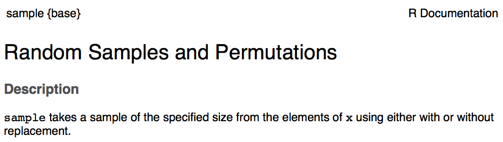

# `sample()`: Usage

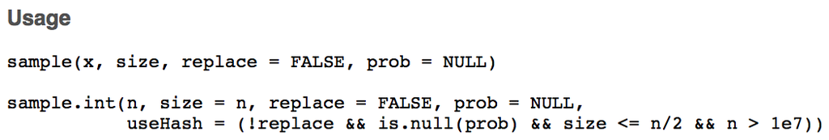

What comes after the `=` sign: default value for that argument

# `sample()`: Arguments

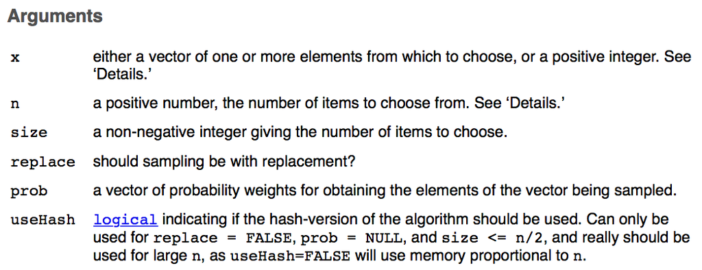

# `sample()`: Details

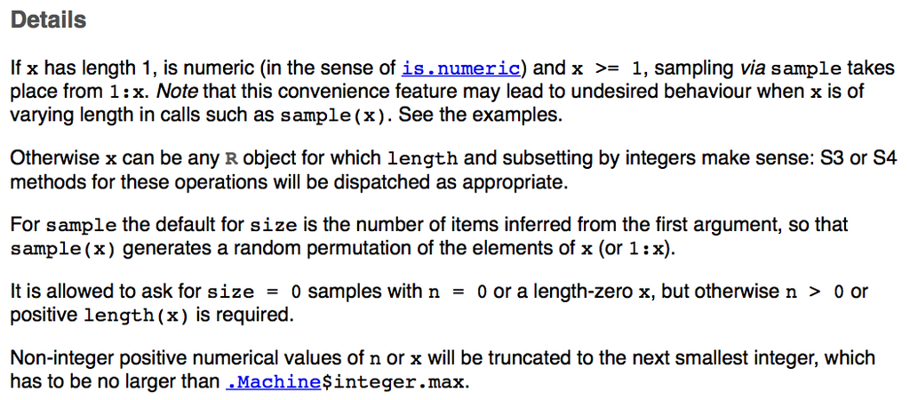

# `sample()`: Value

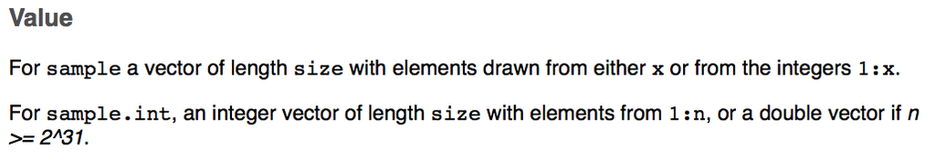

# How does R know which arguments we are referring to?

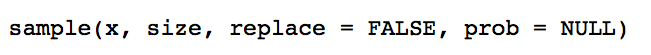

```r
sample(x = 1:10, size = 10)
```

```
##  [1]  3  1  6 10  5  9  2  4  7  8
```

```r
sample(1:10, 10, TRUE)
```

```
##  [1] 10  5 10  4  4  9  4  6  4  3
```

```r
sample(1:10, TRUE, size = 5)
```

```
## [1] 10  1  5  9  5
```